⇑

[beaumont.dev](https://github.com/michaelbeaumont)

# Embedded Rust with LoRa and ePaper - GPIO & Interrupts

Nov. 29, 2020

Embedded Rust is ready; high-quality, production software is being written on industry-standard bare metal microcontrollers. The community has produced so much amazing documentation focusing on the initial stages of using Rust on embedded hardware. With this series I want to move somewhat beyond that, from getting started to more immediate embedded Rust.

We’re going to use Rust to code up a device that takes advantage of multiple hardware peripherals including a display and a radio module. It will be able to broadcast and receive morse code messages using low-power, long range radio ([LoRa](https://www.semtech.com/lora/what-is-lora)) as well as display them on an ePaper screen.

The plan is to first build up a prototype running on a discovery board, then design a custom PCB and finally, a custom case to house everything.

This first few posts will jump right in to initializing and using the peripherals on the discovery board, using the radio and the display, and taking advantage of interrupts and timers. We’ll be using a [B-L072Z-LRWAN1 discovery board](https://www.st.com/en/evaluation-tools/b-l072z-lrwan1.html) with a 2.9-inch, three-color ePaper display from Waveshare.

[video not shown]

SOS

Yes, three-color ePaper really is that slow.

# Goals

This series is written for beginners to embedded development. I want to show how easy it is to quickly get working results with Rust and microcontrollers. At the same time, I want to avoid just dumping information and I want to show how one goes about searching for and finding the details that sometimes seem so elusive when doing embedded development.

This series is specifically written for beginners *to embedded* and I do assume some Rust knowledge. I won’t repeat too much that’s better explained in the amazing [Rust embedded Book](https://rust-embedded.github.io/book) however, so I’ll periodically be linking to passages there. I may also link to source code of the various foundational crates.

We’ll be using existing driver crates to interface with our devices, not delving into raw SPI communication, etc. Still, I ended up making some contributions to these crates for this project so I may dive into the datasheets here or there where it’s interesting.

# Design

Our device should include some way of inputting morse code, transmitting it and displaying responses back to the user.

## Input

We’re going use the big button on our discovery board to input Morse code so let’s have • be a short button press and − be a long button press. While it would be possible to transmit every letter as soon as it’s entered, this would mean the *other* device is constantly drawing to the screen, queueing characters and waiting for the screen to refresh. Let’s instead send strings of characters. We then need a “transmit” input. Let’s make it an *extra* long press!

## Feedback

# Kick off

First, a quick overview of our board. We have the **B-L072Z-LRWAN1** discovery board, which contains our radio module, the **CMWX1ZZABZ-091**. This module runs on a **STM32L072CZ microcontroller**. We’ll mostly be programming against this microcontroller but we’ll find different information and levels of detail by looking at the datasheets and manuals for each of these parts.

We’re starting with a `cargo` project initialized in such a way that we can build and run our application on our B-L072Z-LRWAN1.

###### ⮟ src/main.rs

```rust
#![no_main]
#![no_std]

use crate::hal::{gpio::*, pac, prelude::*};
use cortex_m_rt::entry;
use panic_semihosting as _;
use stm32l0xx_hal as hal;

#[entry]
fn main() -> ! {
    // Get one-time access to our peripherals
    let dp = pac::Peripherals::take().unwrap();

    // Configure the clock at the default speed
    let mut rcc = dp.RCC.freeze(hal::rcc::Config::default());

    // Get access to the GPIO B port
    let gpiob = dp.GPIOB.split(&mut rcc);

    // Setup and turn on green LED
    let mut green_pin = gpiob.pb5.into_push_pull_output();
    green_pin.set_high().unwrap();
    loop {}
}
```

If you want to follow along, make sure you can run [at this point](https://github.com/michaelbeaumont/farsign/tree/v1).

In order to fully understand the code here so far, it may be worth reading the some chapters of the Embedded Book on [the *hardware access layer* system](https://rust-embedded.github.io/book/portability/index.html#what-is-embedded-hal) and [using HAL crates](https://rust-embedded.github.io/book/start/registers.html#using-a-hal-crate).

We’ll mostly be dealing with the HAL crate for our board, [`stm32l0xx_hal`](https://docs.rs/stm32l0xx-hal/0.6.2/stm32l0xx_hal/), which implements `Trait`s defined by [the `embedded-hal` crate](https://docs.rs/embedded-hal/0.2.4/embedded_hal/).

Near the end of this code snippet you’ll notice the magic identifiers `GPIOB` and `pb5`, which give us the GPIO pin attached to our green LED. We know the name of this GPIO port and pin from looking through the [discovery kit schematics](https://www.st.com/resource/en/user_manual/dm00329995-discovery-kit-for-lorawan-sigfox-and-lpwan-protocols-with-stm32l0-stmicroelectronics.pdf) until we found this diagram:

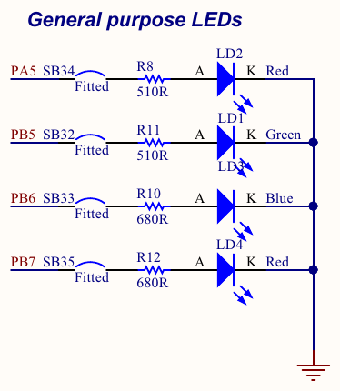

Page 33

This also tells us how to address our blue and red LEDs:

###### ⮟ src/main.rs

```rust
    // Setup and turn on green LED
    let mut green_pin = gpiob.pb5.into_push_pull_output();
    let mut blue_pin = gpiob.pb6.into_push_pull_output();
    let mut red_pin = gpiob.pb7.into_push_pull_output();
    green_pin.set_high().unwrap();
    blue_pin.set_high().unwrap();
    red_pin.set_high().unwrap();
    loop {}
}
```

In order to give feedback on the active press, we’ll need to turn one LED on and the others off. We don’t want to manage our lights color by color all over our project. Our three lights *together* represent the status of our system, so let’s use the type system to express that. We can create a semantically meaningful interface and disallow meaningless configurations, i.e. we already know we’ll only ever have one LED on.

###### ⮟ src/status.rs

```rust
pub struct StatusLights<R, G, B> {
    red: R,
    green: G,
    blue: B,
}

impl<R, G, B> StatusLights<R, G, B> {
    pub fn new(red: R, green: G, blue: B) -> Self {
        StatusLights { red, green, blue }
    }
}
```

Let’s add a function for turning on our blue light for a short press:

###### ⮟ src/status.rs

```rust
    pub fn on_short(&mut self) {
        self.red.set_low().unwrap();
        self.green.set_low().unwrap();
        self.blue.set_high().unwrap();
    }
```

If we try to build at this stage, we get an error:

```rust
error[E0599]: no method named `set_low` found for type parameter `R`
in the current scope
  --> src/status.rs:15:18
   |
15 |         self.red.set_low().unwrap();
   |                  ^^^^^^^ method not found in `R`
   |
   = note: the method `set_low` exists but the following trait bounds
were not satisfied:
           `R: stm32l0xx_hal::prelude::_embedded_hal_digital_OutputPin`
           which is required by `R: stm32l0xx_hal::prelude::OutputPin`
```

That makes sense since our `R`, `G` and `B` types could be anything at this point. We’ll need to add that bound to our `StatusLights` `struct`. If we check the `impl` of that trait for `PB` we also see that the trait has an associated `Error` type which is `Void` in our case:

```rust
impl<MODE> OutputPin for PB<Output<MODE>> {
    type Error = Void

    fn set_high(&mut self) -> Result<(), Self::Error>

    fn set_low(&mut self) -> Result<(), Self::Error>
}
```

Let’s add those bounds to our `impl`:

###### ⮟ src/status.rs

```rust
use crate::hal::prelude::*;
use void::Void;
```

###### ⮟ src/status.rs

```rust
impl<R, G, B> StatusLights<R, G, B> {
impl<R: OutputPin<Error = Void>, G: OutputPin<Error = Void>, B: OutputPin<Error = Void>>
    StatusLights<R, G, B>
{
```

`Void` represents an uninhabited type, a type of which we can never produce a value, ergo `stm32l0xx_hal` has infallible GPIO pin writes.

Instead of restricting `type Error` to `Void`, another option would be to let it be a type argument to our `impl` and add the `Debug` bound, since `unwrap` requires it. This would give us marginally more portability at the cost of complicating our type signatures.

## Interrupts

Let’s start simple and have our button turn off our the lights when pressed and then turn the blue LED on again.

We want to take action when we notice our button has been pressed. What about checking our button in the main loop, something like this:

```rust
let mut leds_on = false;
loop {
    if button_down() && !leds_on {
        leds_on = true;
        // turn off LEDs
    } else if button_up() && leds_on {
        leds_on = false;
        // turn on LEDs
    }
}
```

This is called *polling*, repeatedly checking whether a condition has changed, and it’s a perfectly legitimate way of handling changes. There’s another way though, we can handle events directly as they occur. If you’re not familiar with *interrupts*, the Embedded book goes over [how they work in Rust](https://rust-embedded.github.io/book/start/interrupts.html) and [how exceptions (of which interrupts are a subset) work](https://rust-embedded.github.io/book/start/exceptions.html).

Interrupts have the advantage of immediately triggering an event handler no matter where in our code we’re executing and so allow for a faster response time. Both approaches would work fine in our button case but I want to show you how to setup interrupts for GPIO pins with Rust.

Looking at [our discovery manual](https://www.st.com/resource/en/user_manual/dm00329995-discovery-kit-for-lorawan-sigfox-and-lpwan-protocols-with-stm32l0-stmicroelectronics.pdf) we see it has one user button that’s been wired up to a GPIO port. Let’s see if we can make our light flash off a button press. Let’s create a function that will serve as our interrupt handler:

###### ⮟ src/main.rs

```rust
    red_pin.set_high().unwrap();
    loop {}
}

#[allow(non_snake_case)]
fn INTERRUPT() {
    // handle button press
}
```

### Concurrency

You may have wondered how we can get access to our LEDs in our handler considering it’s called without arguments. In our entry function we use `pac::Peripherals::take()` but remember, we can only call it once. The LEDs need to be shared between our main loop and interrupt handlers. We have *concurrency*, let’s see [what the Embedded book has to say about it](https://rust-embedded.github.io/book/concurrency/).

The TL;DR is that we’ve got two options. One is to put our data in a structure to which Rust will allow us to share access, which is the option we’ll be taking. With `Mutex` we can obtain an exclusive lock on the data contained inside, which allows us to put it in a `static` variable. `static` requires `Sync` as static variables can be accessed from any point in our application. Inside the `Mutex` we put our struct wrapped in a `RefCell`. `RefCell` is necessary to dynamically give us a mutable reference to a single value, the initial struct we create in `main`.

Another option would be to use [a framework](https://rtic.rs/) to manage the boilerplate of creating and accessing these mutexes in interrupt handlers. We should consider this option but I think it’s always useful to understand why and whether frameworks are needed before jumping straight into one. I will likely cover moving our project over to RTIC in a future post.

###### ⮟ src/main.rs

```rust
use stm32l0xx_hal as hal;

static STATUS: Mutex<RefCell<Option<status::StatusLights<?, ?, ?>>>> =
    Mutex::new(RefCell::new(None));

#[entry]
fn main() -> ! {
```

The fact that we’ve bundled our LEDs together into one struct makes dealing with mutexes much more ergonomic.

Our three generic type parameters need to be instantiated with some types representing our LEDs. If we try something (clearly false) we get a pretty helpful error message:

###### ⮟ src/main.rs

```rust
static STATUS: Mutex<RefCell<Option<status::StatusLights<?, ?, ?>>>> =
static STATUS: Mutex<RefCell<Option<status::StatusLights<u64, u64, u64>>>> =
```

###### ⮟ src/main.rs

```rust
    red_pin.set_high().unwrap();
    let status = status::StatusLights::new(red_pin, green_pin, blue_pin);

    cortex_m::interrupt::free(|cs| {
        *STATUS.borrow(cs).borrow_mut() = Some(status);
    });
    loop {}
```

```rust
error[E0308]: mismatched types
  --> src/main.rs:40:48
   |
40 |         *STATUS.borrow(cs).borrow_mut() = Some(status);
   |                                                ^^^^^^ expected `u64`,
found struct `stm32l0xx_hal::gpio::gpiob::PB7`
   |
   = note: expected struct `StatusLights<u64, u64, u64>`
              found struct `StatusLights<
stm32l0xx_hal::gpio::gpiob::PB7<Output<PushPull>>,
stm32l0xx_hal::gpio::gpiob::PB5<Output<PushPull>>,
stm32l0xx_hal::gpio::gpiob::PB6<Output<PushPull>>
>`
```

So we can see that our HAL crate `stm32l0xx_hal` embeds even the pin number we’re using into our type. This may seem like a strange approach at first but the embedded book elaborates [on this idea](https://rust-embedded.github.io/book/static-guarantees/design-contracts.html) and [how to apply it for GPIO](https://rust-embedded.github.io/book/design-patterns/hal/gpio.html).

Writing out these types here isn’t really great for flexibility or readability, though. We can improve things a little bit, our HAL [provides `downgrade` functions on our pins](https://docs.rs/stm32l0xx-hal/0.6.2/stm32l0xx_hal/gpio/gpiob/struct.PB5.html#method.downgrade):

```rust
impl<MODE> PB5<Output<MODE>> {
  pub fn downgrade(self) -> PB<Output<MODE>>
```

We can at least downgrade all of our LEDs into a type representing *some* pin on the GPIO B port.

###### ⮟ src/main.rs

```rust
static STATUS: Mutex<RefCell<Option<status::StatusLights<u64, u64, u64>>>> =
type PBOut = gpiob::PB<Output<PushPull>>;

static STATUS: Mutex<RefCell<Option<status::StatusLights<PBOut, PBOut, PBOut>>>> =
```

###### ⮟ src/main.rs

```rust
    red_pin.set_high().unwrap();
    let status = status::StatusLights::new(red_pin, green_pin, blue_pin);
    let status = status::StatusLights::new(
        red_pin.downgrade(),
        green_pin.downgrade(),
        blue_pin.downgrade(),
    );
```

Now we’re free to get a reference to the status lights in our interrupt handler:

###### ⮟ src/status.rs

```rust
    pub fn off(&mut self) {
        self.red.set_low().unwrap();
        self.green.set_low().unwrap();
        self.blue.set_low().unwrap();
    }
}
```

###### ⮟ src/main.rs

```rust
#[allow(non_snake_case)]
fn INTERRUPT() {
    // handle button press
    cortex_m::interrupt::free(|cs| {
        let mut status = STATUS.borrow(cs).borrow_mut();
        status.as_mut().unwrap().off();
        for _ in 0..10000 {}
        status.as_mut().unwrap().on_short();
    })
}
```

### EXTI

We now have a function that’s ready to handle our interrupt. We’re not done yet, because this interrupt isn’t yet enabled and wired up to our button. First of all, we’ll need our GPIO pin which for our button is `B2` (check [our board manual](https://www.st.com/resource/en/user_manual/dm00329995-discovery-kit-for-lorawan-sigfox-and-lpwan-protocols-with-stm32l0-stmicroelectronics.pdf)), configured as an input:

###### ⮟ src/main.rs

```rust
    let button = gpiob.pb2.into_pull_up_input();
```

If look into our [microcontroller datasheet, chapter 3.7](https://www.st.com/resource/en/datasheet/stm32l072v8.pdf), we read that our we can configure interrupts for changes on GPIO pins. Changes are always either a falling edge (high to low state) or a rising edge (low to high state).

Check out the [microcontroller reference manual](https://www.st.com/resource/en/reference_manual/dm00108281-ultralowpower-stm32l0x2-advanced-armbased-32bit-mcus-stmicroelectronics.pdf), chapter 13, for a very detailed explanation of the responsible peripheral, the **Extended interrupt and Event Controller (EXTI)**. What we need is a link between our button on `PB2` and the name of an interrupt handler. On [page 285 of our microcontroller reference](https://www.st.com/resource/en/reference_manual/dm00108281-ultralowpower-stm32l0x2-advanced-armbased-32bit-mcus-stmicroelectronics.pdf) we find that `PB2` is mapped to the interrupt line `EXTI2`. The idea here is that every pin `x` of each GPIO port is mapped to one `EXTI` interrupt line, i.e. for `EXTI2` we need to select which of the pins `Px2` should trigger the interrupt, which [chapter 10.2.4, page 256](https://www.st.com/resource/en/reference_manual/dm00108281-ultralowpower-stm32l0x2-advanced-armbased-32bit-mcus-stmicroelectronics.pdf) describes.

Looking then at [chapter 12.3, page 280](https://www.st.com/resource/en/reference_manual/dm00108281-ultralowpower-stm32l0x2-advanced-armbased-32bit-mcus-stmicroelectronics.pdf), we find a list of *interrupt vectors* (interrupt handlers) and find an entry at position 6 for `EXTI Line2 and 3 interrupts` with the name `EXTI[3:2]`.

Our `stm32l0xx_hal` crate gives us an API to the EXTI peripheral through the [`Exti`](https://docs.rs/stm32l0xx-hal/0.6.2/stm32l0xx_hal/exti/struct.Exti.html) struct and the [`listen_gpio`](https://docs.rs/stm32l0xx-hal/0.6.2/stm32l0xx_hal/exti/struct.Exti.html#method.listen_gpio) function.

Looking at the function signatures, we need the raw peripherals `EXTI` and `SYSCFG`. Both our `Port` (`PB` in this case) and our [`GpioLine`](https://docs.rs/stm32l0xx-hal/0.6.2/stm32l0xx_hal/exti/struct.GpioLine.html) depend on the pin we’re using. We’ll create both of these dynamically from our `button`. We want to trigger both on rising and falling edges (i.e. we want to be notified when the button is either pressed or released). We use the [`NVIC::unmask` function](https://docs.rs/stm32l0xx-hal/0.6.2/stm32l0xx_hal/pac/struct.NVIC.html#method.unmask) to enable the interrupt handler corresponding to our line, which is an `unsafe` operation.

Put it all together and we have:

###### ⮟ src/main.rs

```rust
    });

    let button = gpiob.pb2.into_pull_up_input();
    let mut exti = Exti::new(dp.EXTI);
    let mut syscfg = syscfg::SYSCFG::new(dp.SYSCFG, &mut rcc);
    let line = GpioLine::from_raw_line(button.pin_number()).unwrap();
    exti.listen_gpio(&mut syscfg, button.port(), line, TriggerEdge::Both);

    unsafe {
        NVIC::unmask(line.interrupt());
    }
```

Finally, we find the interrupt for our line represented by the [`interrupt` enum variant `EXTI2_3`](https://docs.rs/stm32l0xx-hal/0.6.2/stm32l0xx_hal/pac/enum.interrupt.html#variant.EXTI2_3). If we name our function `EXTI2_3` and give it the `interrupt` attribute, we set up our function as the handler for `EXTI[3:2]`:

###### ⮟ src/main.rs

```rust
}

#[allow(non_snake_case)]
fn INTERRUPT() {
#[interrupt]
fn EXTI2_3() {
    cortex_m::interrupt::free(|cs| {
        let mut status = STATUS.borrow(cs).borrow_mut();
        status.as_mut().unwrap().off();
        for _ in 0..10000 {}
        status.as_mut().unwrap().on_short();
    })
}
```

If we run our application now, we can see our lights go off and then on in response to a button press! But… it keeps blinking after releasing the button…

The way interrupts work requires us to manually clear the interrupt, otherwise it will keep firing over and over again. We’ll add a `Mutex` for our button so we can get the pin number.

###### ⮟ src/main.rs

```rust
static STATUS: Mutex<RefCell<Option<status::StatusLights<PBOut, PBOut, PBOut>>>> =
    Mutex::new(RefCell::new(None));
static BUTTON: Mutex<RefCell<Option<gpiob::PB2<Input<PullUp>>>>> = Mutex::new(RefCell::new(None));
```

###### ⮟ src/main.rs

```rust
    cortex_m::interrupt::free(|cs| {
        *STATUS.borrow(cs).borrow_mut() = Some(status);
    });

    let button = gpiob.pb2.into_pull_up_input();
    let mut exti = Exti::new(dp.EXTI);
    let mut syscfg = syscfg::SYSCFG::new(dp.SYSCFG, &mut rcc);
    let line = GpioLine::from_raw_line(button.pin_number()).unwrap();
    exti.listen_gpio(&mut syscfg, button.port(), line, TriggerEdge::Both);

    cortex_m::interrupt::free(|cs| {
        *STATUS.borrow(cs).borrow_mut() = Some(status);
        *BUTTON.borrow(cs).borrow_mut() = Some(button);
    });
```

###### ⮟ src/main.rs

```rust
fn EXTI2_3() {
    cortex_m::interrupt::free(|cs| {
        let pin_number = BUTTON.borrow(cs).borrow().as_ref().unwrap().pin_number();
        Exti::unpend(GpioLine::from_raw_line(pin_number).unwrap());
        let mut status = STATUS.borrow(cs).borrow_mut();
```

One final feature we can add is checking whether the button is pressed or released. Right now you’ll notice we treat a release the same as a press. Let’s keep our LED off while pressed and turn it back on when released. To do this we need to check the level of our pin in our interrupt.

###### ⮟ src/main.rs

```rust
fn EXTI2_3() {
    cortex_m::interrupt::free(|cs| {
        let pin_number = BUTTON.borrow(cs).borrow().as_ref().unwrap().pin_number();
        let (pin_number, is_low) = BUTTON
            .borrow(cs)
            .borrow()
            .as_ref()
            .map(|p| (p.pin_number(), p.is_low().unwrap()))
            .unwrap();
        Exti::unpend(GpioLine::from_raw_line(pin_number).unwrap());
        let mut status = STATUS.borrow(cs).borrow_mut();
        status.as_mut().unwrap().off();
        for _ in 0..10000 {}
        status.as_mut().unwrap().on_short();
        if is_low {
            status.as_mut().unwrap().off();
        } else {
            status.as_mut().unwrap().on_short();
        }
    })
```

That may seem like a lot of code for turning off and on an LED but it will serve as the basis for the rest of our project.

[video not shown]

Blinky button

In the next installment we’re going to look at using our ePaper display.